# Bechdel + Programming

Nicholas Duran & Jessica Kosie[^1]

Mine Çetinkaya-Rundel[^2]

25 August, 2025

In this mini analysis we work with the data used in the FiveThirtyEight story titled [“The Dollar-And-Cents Case Against Hollywood’s Exclusion of Women”](https://fivethirtyeight.com/features/the-dollar-and-cents-case-against-hollywoods-exclusion-of-women/).

```r
?bechdel
```

```
## No documentation for 'bechdel' in specified packages and libraries:
## you could try '??bechdel'
```

We will be working with the results of a Bechdel test (this is a way of evaluating whether a work of fiction portrays women in a way that is sexist or characterized by gender stereotyping).

To pass the Bechdel test, the film must pass three criteria:

- the movie must have at least two women in it
- the women must talk to each other
- the women must talk to each other about something other than a man

Your task is to fill in the blanks denoted by `___`.

## Data and packages

We start with loading the packages we’ll use.

I like to click the gear above and choose “Chunk Output in Console” so that the output is displayed below rather than in this doc.

```r
library(fivethirtyeight)
library(tidyverse)
```

Now, let’s check out our data. After reading in the data, you should *always* take a look to make sure it is the correct data / loaded correctly / etc!

```r
View(bechdel)
head(bechdel)
```

```
## # A tibble: 6 × 15
##    year imdb      title   test  clean_test binary budget domgross intgross code
##   <int> <chr>     <chr>   <chr> <ord>      <chr>   <int>    <dbl>    <dbl> <chr>
## 1  2013 tt1711425 21 & O… nota… notalk     FAIL   1.3 e7 25682380   4.22e7 2013…
## 2  2012 tt1343727 Dredd … ok-d… ok         PASS   4.50e7 13414714   4.09e7 2012…
## 3  2013 tt2024544 12 Yea… nota… notalk     FAIL   2   e7 53107035   1.59e8 2013…
## 4  2013 tt1272878 2 Guns  nota… notalk     FAIL   6.1 e7 75612460   1.32e8 2013…
## 5  2013 tt0453562 42      men   men        FAIL   4   e7 95020213   9.50e7 2013…
## 6  2013 tt1335975 47 Ron… men   men        FAIL   2.25e8 38362475   1.46e8 2013…
## # ℹ 5 more variables: budget_2013 <int>, domgross_2013 <dbl>,
## #   intgross_2013 <dbl>, period_code <int>, decade_code <int>
```

The dataset contains information on 1794 movies released between 1970 and 2013.

However we’ll focus our analysis on movies released between 1990 and 2013.

*TODO: we want to get a specific, narrower range of movies, which means we need to ignore some rows of our dataframe*

```r
bechdel90_13 <- bechdel %>% ## note the "<-" assignment operator
  filter(between(year, 1990, 2013))
```

There are 1615 such movies.

The financial variables we’ll focus on are the following:

- `budget_2013`: Budget in 2013 inflation adjusted dollars
- `domgross_2013`: Domestic gross (US) in 2013 inflation adjusted dollars
- `intgross_2013`: Total International (i.e., worldwide) gross in 2013 inflation adjusted dollars

And we’ll also use the `binary` and `clean_test` variables for **grouping**.

## Analysis

Let’s take a look at how median budget and gross vary by whether the movie passed the Bechdel test, which is stored in the `binary` variable.

*TODO: we want to get some stats on the various financial variables by whether they passed or failed the Bechdel test, i.e., groups*

```r
bechdel90_13 %>%
  group_by(binary) %>%
  summarise(med_budget = median(budget_2013),
            med_domgross = median(domgross_2013, na.rm = TRUE),
            med_intgross = median(intgross_2013, na.rm = TRUE))
```

```
## # A tibble: 2 × 4
##   binary med_budget med_domgross med_intgross
##   <chr>       <dbl>        <dbl>        <dbl>
## 1 FAIL    48385984.    57318606.    104475669
## 2 PASS    31070724     45330446.     80124349
```

Next, let’s take a look at how median budget and gross vary by a more detailed indicator of the Bechdel test result.

This information is stored in the `clean_test` variable, which takes on the following values:

- `ok` = passes test
- `dubious` = skeptical about whether it passes the test
- `men` = women only talk about men
- `notalk` = women don’t talk to each other
- `nowomen` = fewer than two women

*TODO: repeat what we did above, but grouping the stats by more refined categories*

```r
bechdel90_13 %>%
  group_by(clean_test) %>%
  summarize(med_budget = median(budget_2013),
             med_domgross = median(domgross_2013, na.rm = TRUE),
             med_intgross = median(intgross_2013, na.rm = TRUE)                )
```

```
## # A tibble: 5 × 4
##   clean_test med_budget med_domgross med_intgross
##   <ord>           <dbl>        <dbl>        <dbl>
## 1 nowomen     43373066     44891296.    89509349
## 2 notalk      56570084.    63890455    123102194
## 3 men         39737690.    56392786     99578022.
## 4 dubious     35790994     49173429     89883201
## 5 ok          31070724     45330446.    80124349
```

In order to evaluate how return on investment varies among movies that pass and fail the Bechdel test, we’ll first create a new variable called `roi` as the ratio of the gross to budget.

*TODO: create a new variable based on criteria we need to specify*

```r
bechdel90_13 <- bechdel90_13 %>% ## note the "<-" assignment operator
  mutate(roi = (domgross_2013 + intgross_2013) / budget_2013 )
```

Let’s see which movies have the highest return on investment.

*TODO: sort the data by roi (highest to lowest)*

```r
bechdel90_13 %>%
  arrange(desc(roi)) %>%
  select(title, roi, year, clean_test) # do we want all the columns? let's return the columns that are most important here
```

```
## # A tibble: 1,615 × 4
##    title                     roi  year clean_test
##    <chr>                   <dbl> <int> <ord>
##  1 Paranormal Activity      671.  2007 dubious
##  2 The Blair Witch Project  648.  1999 ok
##  3 El Mariachi              583.  1992 nowomen
##  4 Clerks.                  258.  1994 notalk
##  5 In the Company of Men    231.  1997 notalk
##  6 Napoleon Dynamite        227.  2004 notalk
##  7 Once                     190.  2006 men
##  8 The Devil Inside         155.  2012 ok
##  9 Primer                   142.  2004 notalk
## 10 Fireproof                134.  2008 men
## # ℹ 1,605 more rows
```

Below is a visualization of the return on investment by test result, however it’s difficult to see the distributions due to a few extreme observations.

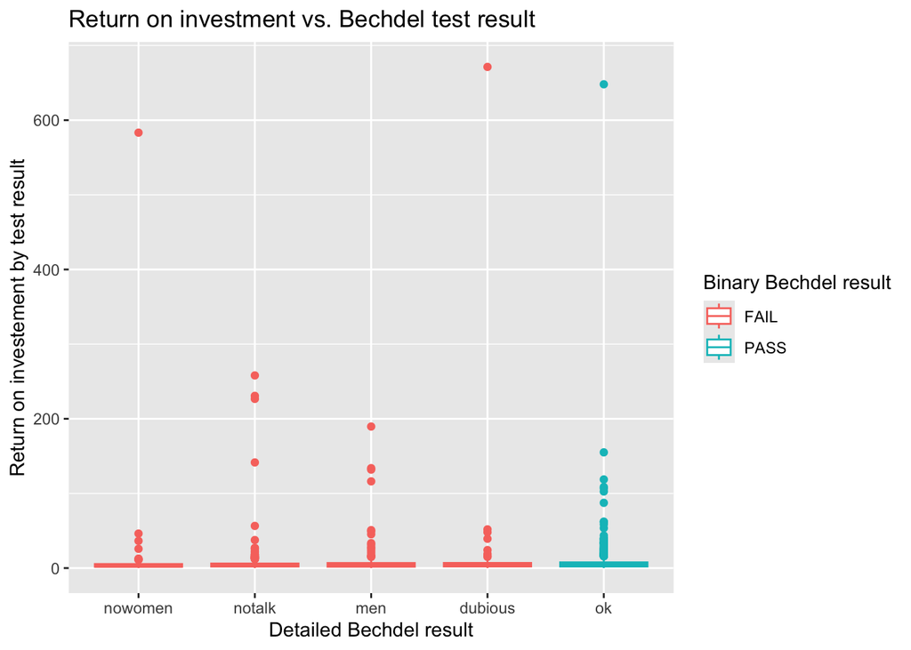

```r
ggplot(data = bechdel90_13,
       mapping = aes(x = clean_test, y = roi, color = binary)) +
  geom_boxplot() +
  labs(title = "Return on investment vs. Bechdel test result",
       x = "Detailed Bechdel result",
       y = "Return on investement by test result",
       color = "Binary Bechdel result")
```

What are those movies with *very* high returns on investment?

```r
bechdel90_13 %>%
  filter(roi > 400) %>%
  select(title, budget_2013, domgross_2013, year)
```

```
## # A tibble: 3 × 4
##   title                   budget_2013 domgross_2013  year
##   <chr>                         <int>         <dbl> <int>
## 1 Paranormal Activity          505595     121251476  2007
## 2 The Blair Witch Project      839077     196538593  1999
## 3 El Mariachi                   11622       3388636  1992
```

*TODO: figure out how to do this zooming in; also don’t forget to add a subtitle indicating that it was done*

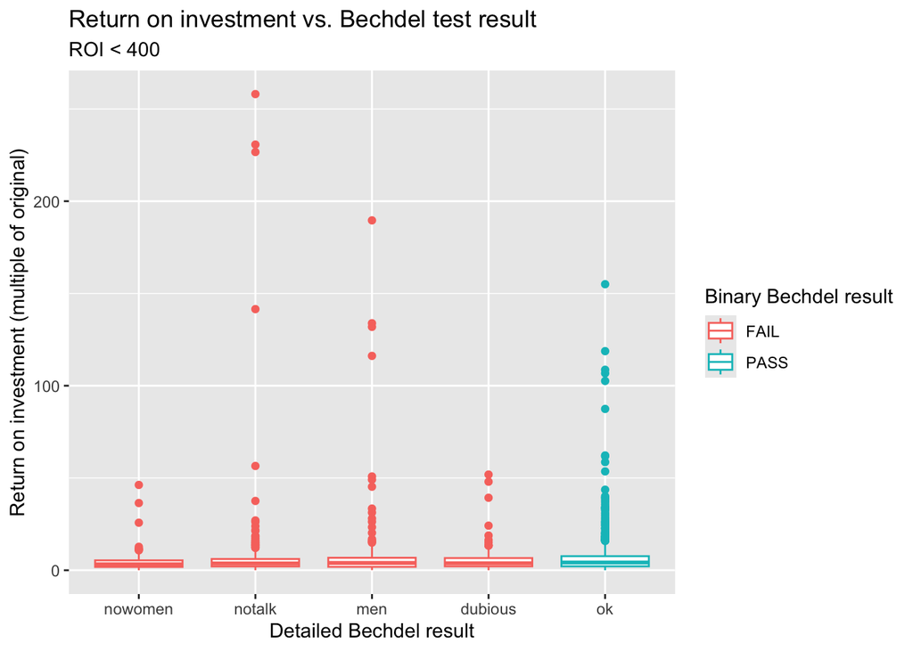

```r
bechdel90_13_zoom400 <- bechdel90_13 %>%
  filter(roi < 400)

ggplot(data = bechdel90_13_zoom400, mapping = aes(x = clean_test, y = roi, color = binary)) +
  geom_boxplot() +
  labs(title = "Return on investment vs. Bechdel test result",
      subtitle = "ROI < 400", # Something about zooming in to a certain level
       x = "Detailed Bechdel result",
       y = "Return on investment (multiple of original)",
       color = "Binary Bechdel result")
```

[^1]: Authored modifications to original code
[^2]: Original author of exercise